# Deployment

2023-05-02

# Data preprocessing

```r
data_bikes <- read.csv("C:/Users/mperi/GCD/3/EDM/prácticas/Practica 5 Sin sol/day.csv")

# Data preprocessing
seasons_onehot <- model.matrix(~ as.factor(data_bikes$season) - 1)
data_bikes$season_spring <- seasons_onehot[, 2]
data_bikes$season_summer <- seasons_onehot[, 3]
data_bikes$season_fall <- seasons_onehot[, 4]

# Creates MISTY and RAIN features
data_bikes$MISTY <- as.integer(data_bikes$weathersit == 2)
data_bikes$RAIN <- as.integer(data_bikes$weathersit %in% c(3, 4))
# Denormalization based on "Dataset description.pdf" explanations.
t_min <- -8
t_max <- 39
data_bikes$temp <- data_bikes$temp * (t_max - t_min) + t_min
data_bikes$hum <- data_bikes$hum * 100
wind_max <- 67
data_bikes$windspeed <- data_bikes$windspeed * wind_max

# Creates days_since_2011 feature to save the number of days from 1-1-2011 for each sample
data_bikes$dteday <- as.Date(data_bikes$dteday)
start_date <- as.Date("2011-01-01")
data_bikes$days_since_2011 <- as.numeric(data_bikes$dteday - start_date)
```

# 1. One dimensional Partial Dependence Plot (PDP)

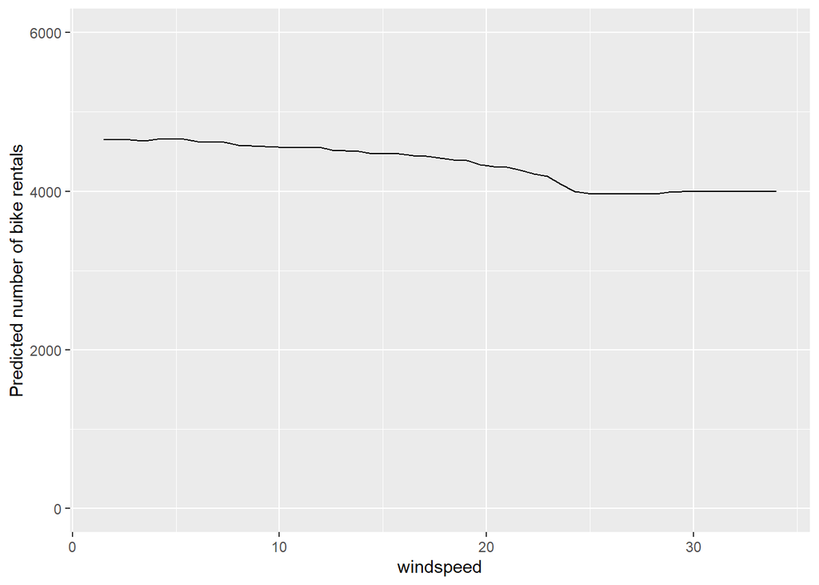

```r
# Definir las variables predictoras y la variable objetivo
predictors <- data_bikes[, c("workingday", "holiday", "season_spring", "season_summer","season_fall", "MISTY", "RAIN", "temp", "hum", "windspeed", "days_since_2011")]

target <- data_bikes$cnt

# Entrenar el modelo de bosque aleatorio
rf_model <- randomForest(predictors, target, ntree=100, importance=TRUE)

# Crear PDP para otras características de interés

pdp_wind <- partial(rf_model, pred.var = "windspeed", plot = TRUE, plot.engine = "ggplot2") + ylab("Predicted number of bike rentals") + scale_y_continuous(limits = c(0, 6000))

pdp_hum <- partial(rf_model, pred.var = "hum", plot = TRUE,
                   plot.engine = "ggplot2") + ylab("Predicted number of bike rentals") + scale_y_continuous(limits = c(0, 6000))

pdp_temp <- partial(rf_model, pred.var = "temp", plot = TRUE,plot.engine = "ggplot2") + ylab("Predicted number of bike rentals") + scale_y_continuous(limits = c(0, 6000))

pdp_2011 <- partial(rf_model, pred.var = "days_since_2011", plot = TRUE, plot.engine = "ggplot2") + ylab("Predicted number of bike rentals") + scale_y_continuous(limits = c(0, 6000))

plot(pdp_wind)
```

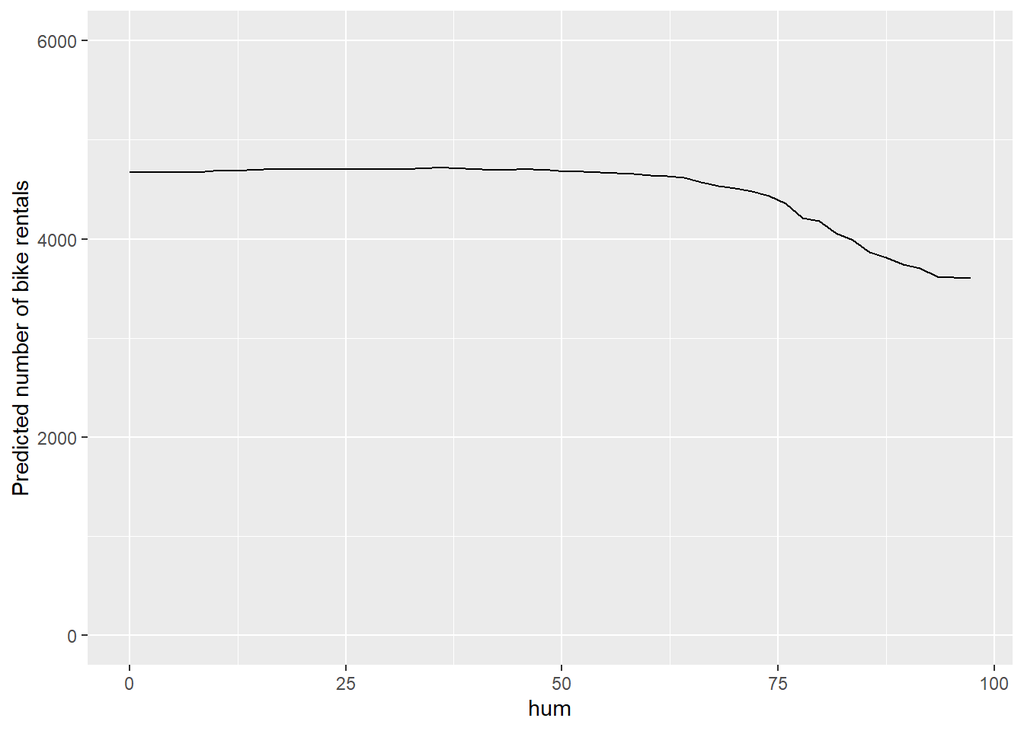

```r
plot(pdp_hum)
```

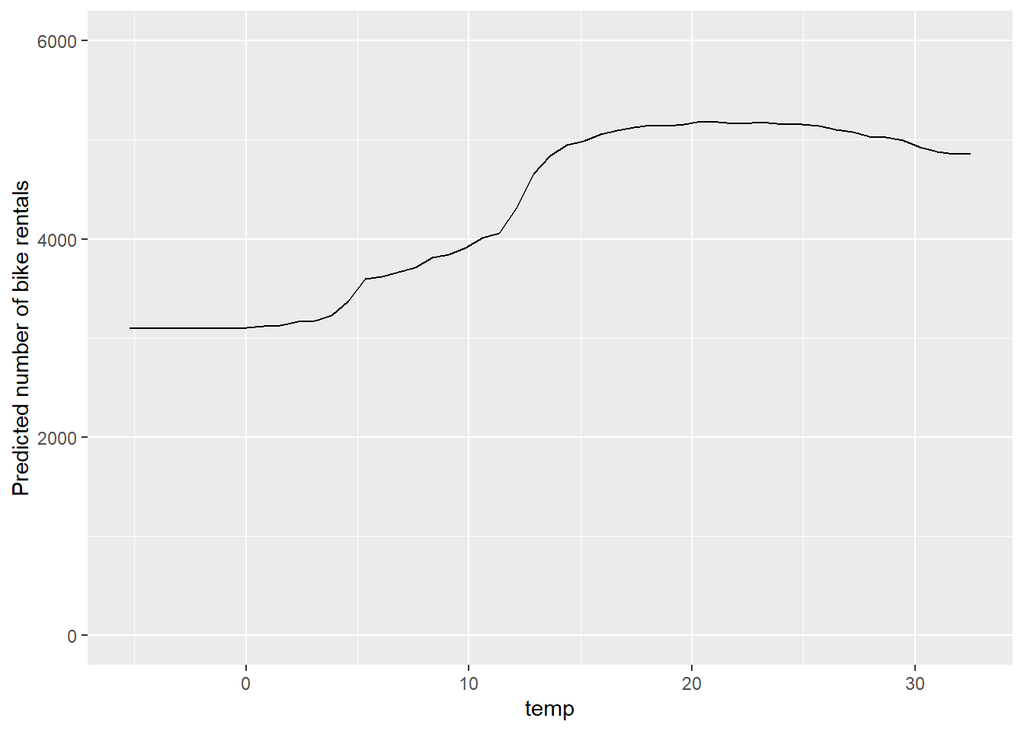

```r
plot(pdp_temp)
```

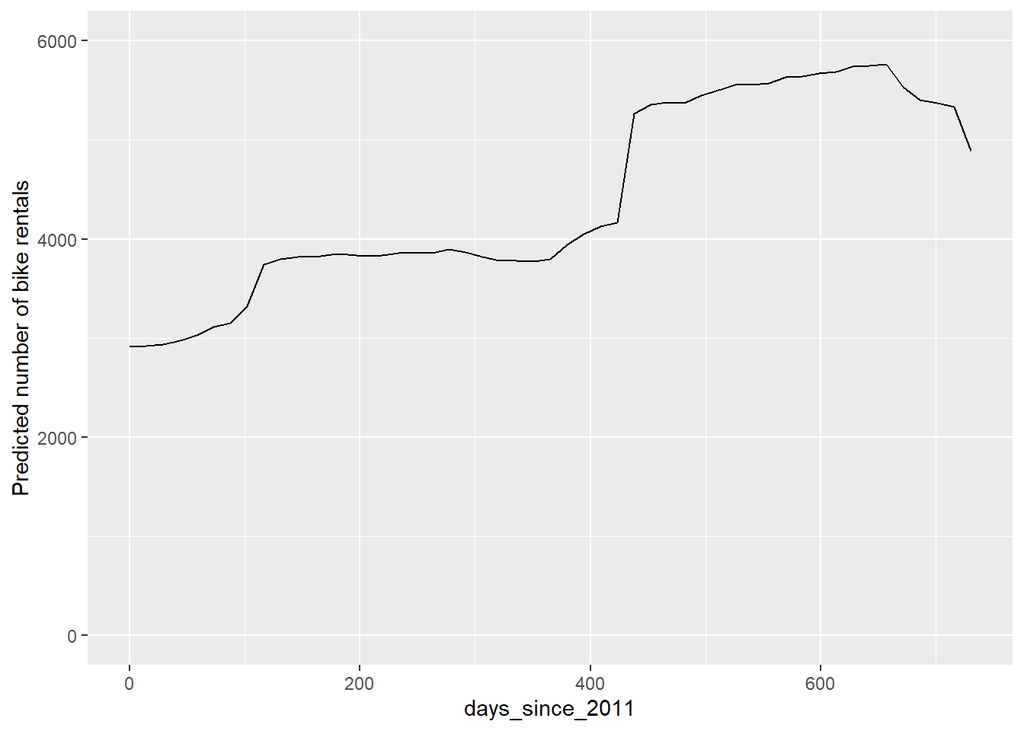

```r
plot(pdp_2011)
```

## Analyse the influence of days since 2011, temperature, humidity and wind speed on the predicted bike counts.

By observing the obtained graphs, we can draw the following conclusions regarding the behavior of bicycle rentals based on the specified variables in the statement:

Windspeed: Wind speed and bicycle usage have an inversely proportional relationship. Higher wind speeds result in lower bicycle usage. The optimal wind speed for higher bicycle usage is around 5 km/h, where approximately 4700 bicycles are rented.

Hum: In this case, the demand for bicycle usage remains stable at around 4,600. However, when humidity exceeds approximately 65, bicycle usage starts to decline, reaching as low as 3600 daily uses.

Days_since_2011: This graph exhibits more variations compared to the others, where we can see a clearer pattern. Nonetheless, despite the increasing and decreasing curves, we can observe that since the start of 2011, bicycle rentals have been increasing, reaching a peak of nearly 6000 uses on day 650 (day 1 being 01/01/2011).

Therefore, we can conclude that the optimal conditions for higher bicycle rentals involve minimal wind speed, moderate humidity (between 40 and 65), and a temperature range that is neither too low nor too high (between 15 and 20). Additionally, bicycle rentals have been increasing since the beginning of 2011.

#2. Bidimensional Partial Dependency Plot

```r
# Extract a set of random samples from the BBDD before generating the data for the Partial Dependency Plot.

bike_sample <- data_bikes %>% sample_n(size = 400, replace = FALSE)
```

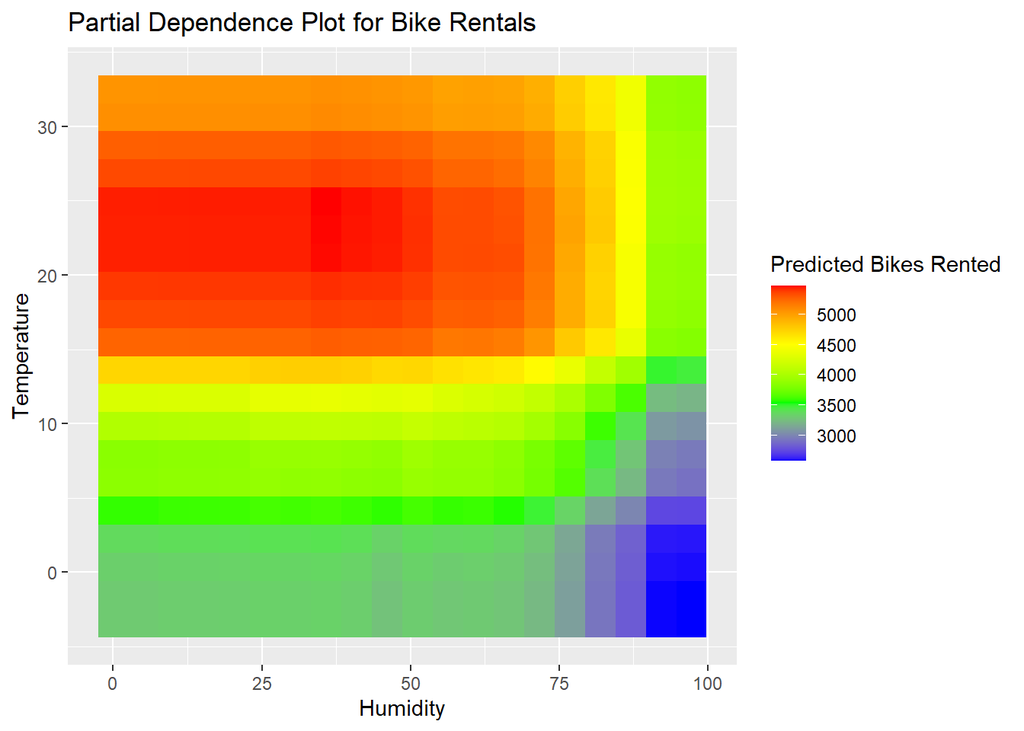

```r
predictors_sample <- bike_sample[, c("workingday", "holiday", "season_spring", "season_summer","season_fall", "MISTY", "RAIN", "temp", "hum", "windspeed", "days_since_2011")]

target_sample <- bike_sample$cnt

# Fit random forest model
rf_model_sample <- randomForest(predictors_sample, target_sample, ntree=100, importance=TRUE)

# Generate PDP
bike_pdp <- partial(rf_model_sample, pred.var = c("hum", "temp"), grid.resolution = 20, plot = TRUE, plot.engine = "ggplot2") + geom_tile(width = 0.1, height = 0.1) + scale_fill_gradientn(colors = c("blue", "green", "yellow", "red")) + labs(title = "Partial Dependence Plot for Bike Rentals", x = "Humidity", y = "Temperature", fill = "Predicted Bikes Rented")

bike_pdp
```

## Interpret the results

In the obtained heat map, we can confirm part of the information obtained in the graphs from exercise 1, as we once again observe that there is higher demand for bicycle rentals when the temperature is not very low (between -6 and 4) and not very high (rentals start to decrease above 26). In this case, we have obtained a broader range for optimizing rentals based on temperature (increasing from 4 to 25), but the results remain the same.

Additionally, we can see that humidity does not influence the behavior as much, but it does confirm once again that rentals decrease when humidity is higher, regardless of the temperature.

# 3.PDP to explain the price of a house.

```r
house_data <- read.csv("C:/Users/mperi/GCD/3/EDM/prácticas/Practica 5 Sin sol/kc_house_data.csv")
house_sample <- house_data %>% sample_n(size = 10000, replace = FALSE)
```

```r
predictors_house <- house_sample[, c("bedrooms", "bathrooms", "sqft_living", "sqft_lot", "floors", "yr_built")]

target_house <- house_sample$price

rf_house <- randomForest(predictors_house, target_house, ntree=100, importance=TRUE)
```

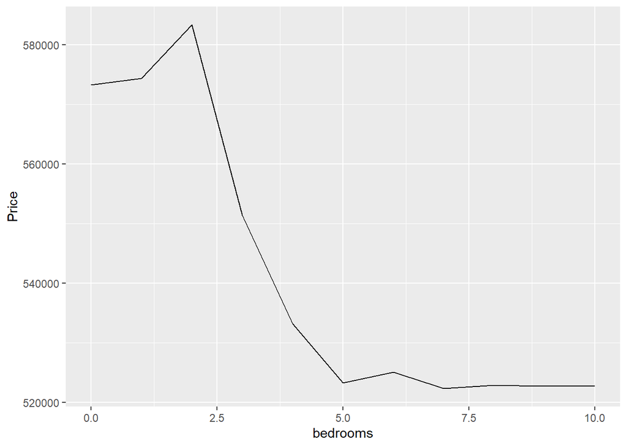

```r
# PDP plot
pdp_bed <- partial(rf_house, pred.var = "bedrooms", plot = TRUE, plot.engine = "ggplot2") + ylab("Price")

pdp_bath <- partial(rf_house, pred.var = "bathrooms", plot = TRUE, plot.engine = "ggplot2") + ylab("Price") + scale_y_continuous(labels = scales::number_format(scale = 1, big.mark = ""))

pdp_sqft <- partial(rf_house, pred.var = "sqft_living", plot = TRUE,plot.engine = "ggplot2") + ylab("Price")

pdp_floors <- partial(rf_house, pred.var = "floors", plot = TRUE, plot.engine = "ggplot2") + ylab("Price")

plot(pdp_bed)
```

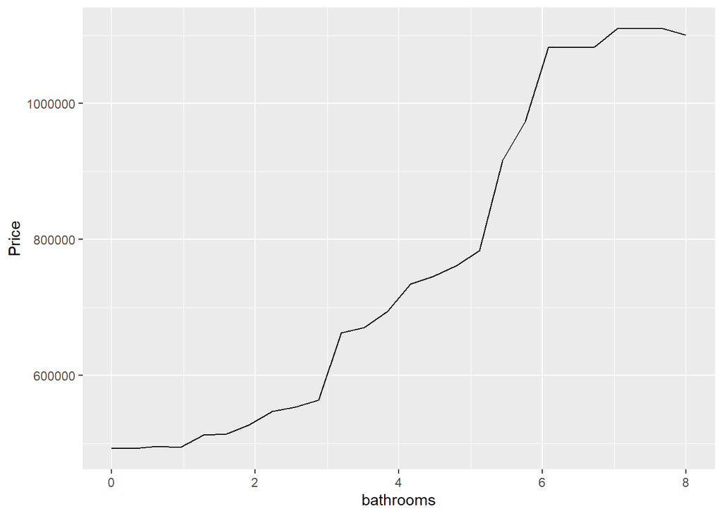

```r
plot(pdp_bath)
```

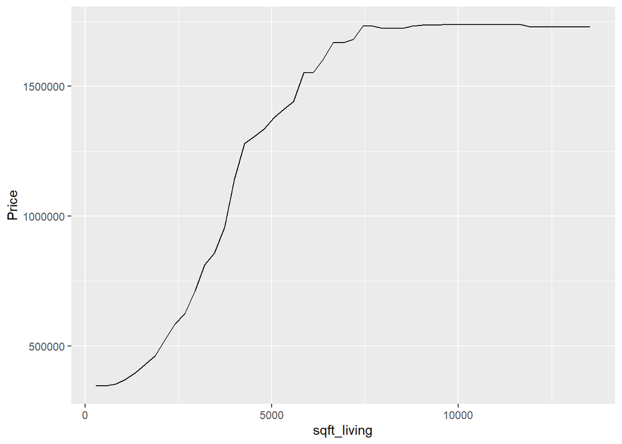

```r
plot(pdp_sqft)
```

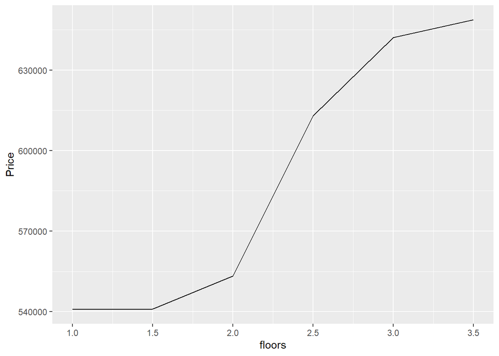

```r
plot(pdp_floors)
```

## Analyse the influence of bedrooms, bathrooms, sqft_living and floors on the predicted price.

These graphs show us that the number of bedrooms in a house has a different influence compared to the number of bathrooms, the quantity of floors, and the living space.